# Hierarchical Clustering

Harika

11/14/2019

The dataset Cereals.csv includes nutritional information, store display, and consumer ratings for 77 breakfast cereals. Data Preprocessing. Remove all cereals with missing values.

```r
#Data preprocessing
#Import data file
cereal <- read.csv("Cereals.csv")
str(cereal)
```

```
## 'data.frame':    77 obs. of  16 variables:
##  $ name    : Factor w/ 77 levels "100%_Bran","100%_Natural_Bran",..: 1 2 3 4 5 6 7 8 9 10 ...
##  $ mfr     : Factor w/ 7 levels "A","G","K","N",..: 4 6 3 3 7 2 3 2 7 5 ...
##  $ type    : Factor w/ 2 levels "C","H": 1 1 1 1 1 1 1 1 1 1 ...
##  $ calories: int  70 120 70 50 110 110 110 130 90 90 ...
##  $ protein : int  4 3 4 4 2 2 2 3 2 3 ...
##  $ fat     : int  1 5 1 0 2 2 0 2 1 0 ...
##  $ sodium  : int  130 15 260 140 200 180 125 210 200 210 ...
##  $ fiber   : num  10 2 9 14 1 1.5 1 2 4 5 ...
##  $ carbo   : num  5 8 7 8 14 10.5 11 18 15 13 ...
##  $ sugars  : int  6 8 5 0 8 10 14 8 6 5 ...
##  $ potass  : int  280 135 320 330 NA 70 30 100 125 190 ...
##  $ vitamins: int  25 0 25 25 25 25 25 25 25 25 ...
##  $ shelf   : int  3 3 3 3 3 1 2 3 1 3 ...
##  $ weight  : num  1 1 1 1 1 1 1 1.33 1 1 ...
##  $ cups    : num  0.33 1 0.33 0.5 0.75 0.75 1 0.75 0.67 0.67 ...
##  $ rating  : num  68.4 34 59.4 93.7 34.4 ...
```

```r
head(cereal)
```

```
##                        name mfr type calories protein fat sodium fiber
## 1                 100%_Bran   N    C       70       4   1    130  10.0
## 2         100%_Natural_Bran   Q    C      120       3   5     15   2.0
## 3                  All-Bran   K    C       70       4   1    260   9.0
## 4 All-Bran_with_Extra_Fiber   K    C       50       4   0    140  14.0
## 5            Almond_Delight   R    C      110       2   2    200   1.0
## 6   Apple_Cinnamon_Cheerios   G    C      110       2   2    180   1.5
##   carbo sugars potass vitamins shelf weight cups   rating
## 1   5.0      6    280       25     3      1 0.33 68.40297
## 2   8.0      8    135        0     3      1 1.00 33.98368
## 3   7.0      5    320       25     3      1 0.33 59.42551
## 4   8.0      0    330       25     3      1 0.50 93.70491
## 5  14.0      8     NA       25     3      1 0.75 34.38484
## 6  10.5     10     70       25     1      1 0.75 29.50954
```

```r
#Removing missing values
data_cereal <- na.omit(cereal)

#Normalizing the data
data_cereal <- scale(data_cereal[,c(4:16)])
summary(data_cereal)
```

```
##     calories          protein              fat              sodium
##  Min.   :-2.8738   Min.   :-1.40687   Min.   :-0.9932   Min.   :-1.9616
##  1st Qu.:-0.3541   1st Qu.:-0.47733   1st Qu.:-0.9932   1st Qu.:-0.3306
##  Median : 0.1498   Median :-0.01256   Median : 0.0000   Median : 0.2131
##  Mean   : 0.0000   Mean   : 0.00000   Mean   : 0.0000   Mean   : 0.0000
##  3rd Qu.: 0.1498   3rd Qu.: 0.45221   3rd Qu.: 0.0000   3rd Qu.: 0.6661
##  Max.   : 2.6695   Max.   : 3.24083   Max.   : 3.9729   Max.   : 1.9045
##      fiber              carbo              sugars            potass
##  Min.   :-0.89778   Min.   :-2.50014   Min.   :-1.6306   Min.   :-1.1783
##  1st Qu.:-0.79462   1st Qu.:-0.70143   1st Qu.:-0.9424   1st Qu.:-0.8079
##  Median :-0.07249   Median :-0.05903   Median :-0.0248   Median :-0.1201
##  Mean   : 0.00000   Mean   : 0.00000   Mean   : 0.0000   Mean   : 0.0000
##  3rd Qu.: 0.34015   3rd Qu.: 0.58337   3rd Qu.: 0.8928   3rd Qu.: 0.3031
##  Max.   : 4.87925   Max.   : 2.12512   Max.   : 1.8104   Max.   : 3.2660
##     vitamins           shelf             weight             cups
##  Min.   :-1.3032   Min.   :-1.4617   Min.   :-3.4600   Min.   :-2.4251
##  1st Qu.:-0.1818   1st Qu.:-1.1612   1st Qu.:-0.2008   1st Qu.:-0.6432
##  Median :-0.1818   Median :-0.2599   Median :-0.2008   Median :-0.3038
##  Mean   : 0.0000   Mean   : 0.0000   Mean   : 0.0000   Mean   : 0.0000
##  3rd Qu.:-0.1818   3rd Qu.: 0.9420   3rd Qu.:-0.2008   3rd Qu.: 0.7568
##  Max.   : 3.1822   Max.   : 0.9420   Max.   : 3.0583   Max.   : 2.8780
##      rating
##  Min.   :-1.7336
##  1st Qu.:-0.7071
##  Median :-0.1510
##  Mean   : 0.0000
##  3rd Qu.: 0.5807
##  Max.   : 3.6578
```

1. Apply hierarchical clustering to the data using Euclidean distance to the normalized measurements. Use Agnes to compare the clustering from single linkage, complete linkage, average linkage, and Ward. Choose the best method.

```r
library(GGally)
library(dplyr)
library(tidyverse)
library(cluster)
library(factoextra)
```

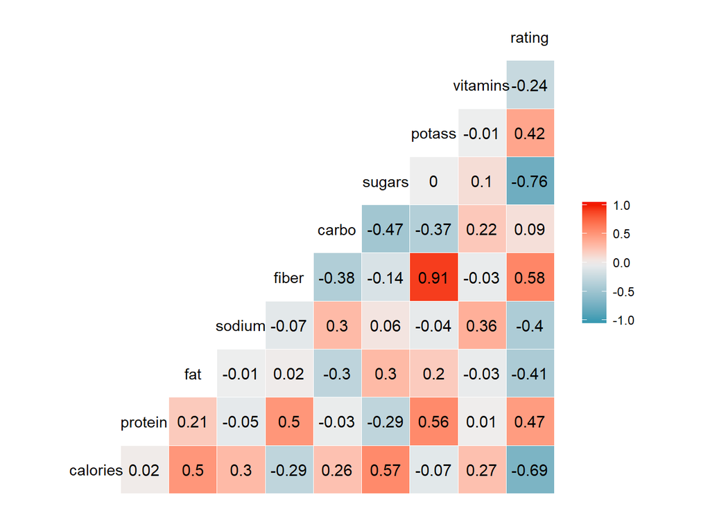

```r
library(dendextend) # for comparing two dendrograms
library(fpc)
library(NbClust)
library(compareDF)
library(caret)
#correlation between variables

cereal %>%
  select(calories, protein, fat, sodium, fiber, carbo, sugars, potass,vitamins,rating) %>%
  ggcorr( label = TRUE, label_round =  2)
```

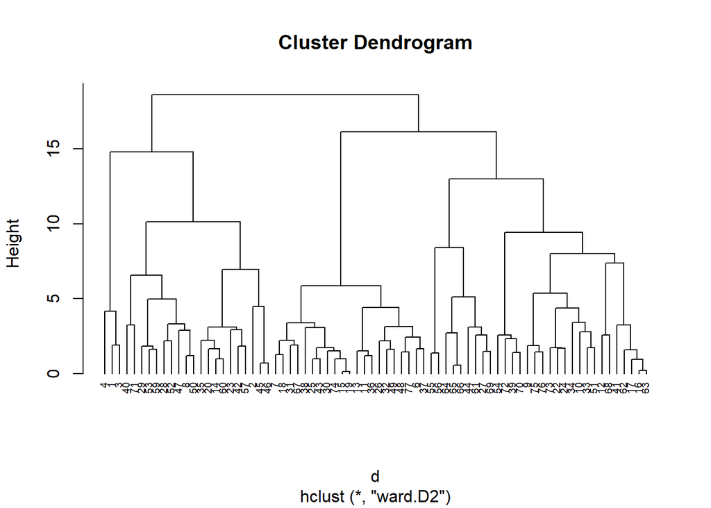

```r
#Euclidean method as distance
d <- dist(data_cereal,method = "euclidean")

#Appling hierarchical clustering using WARD method
hc1 <- hclust(d,method = "ward.D2")

#Plotting dendogram
plot(hc1,cex=0.6,hang = -1)
```

```r
#Using agnes to compare different clustering methods.
#Single Linkage
hc_single <- agnes(data_cereal,method="single")
print(hc_single$ac)
```

```
## [1] 0.6067859
```

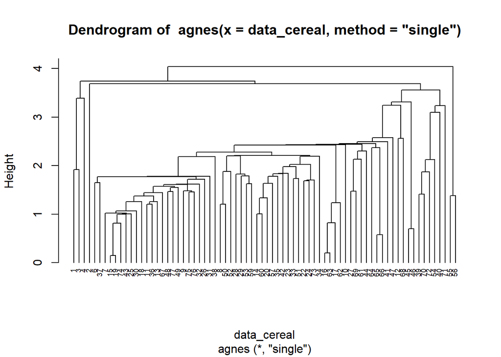

```r
pltree(hc_single, cex = 0.6, hang = -1)
```

```r
#complete linkage
hc_complete <- agnes(data_cereal,method="complete")
print(hc_complete$ac)
```

```
## [1] 0.8353712
```

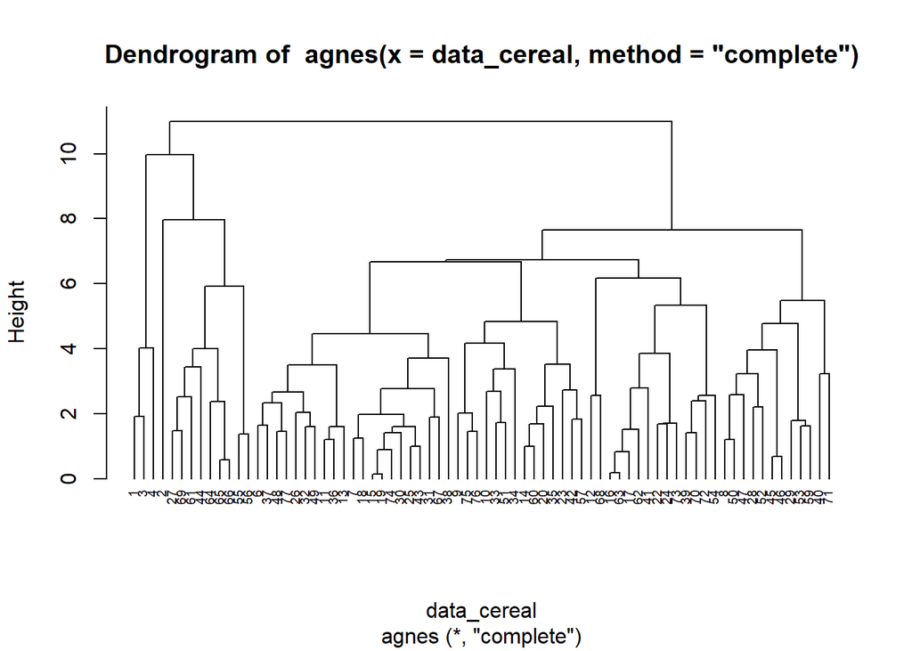

```r
pltree(hc_complete, cex = 0.6, hang = -1)
```

```r
#average linkage
hc_average <- agnes(data_cereal,method="average")
print(hc_average$ac)
```

```
## [1] 0.7766075
```

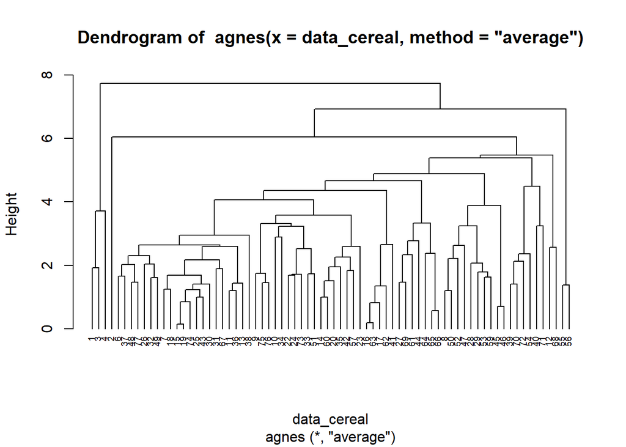

```r
pltree(hc_average, cex = 0.6, hang = -1)
```

```r
#Ward method
hc_ward <- agnes(data_cereal,method="ward")
print(hc_ward$ac)
```

```
## [1] 0.9046042
```

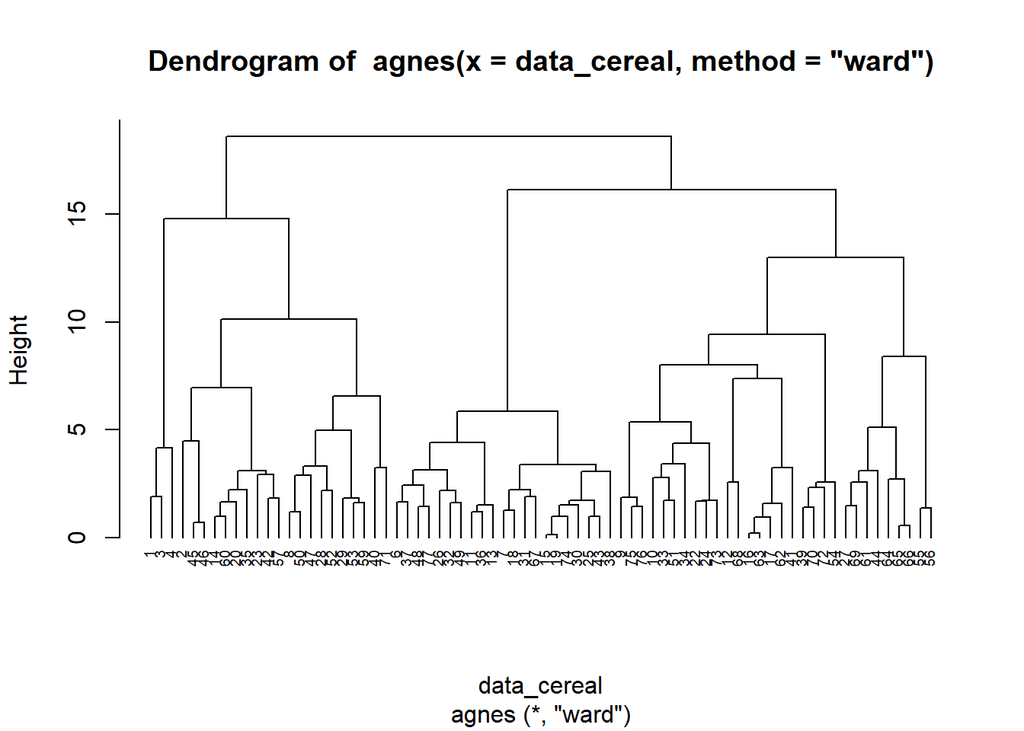

```r
pltree(hc_ward, cex = 0.6, hang = -1)
```

```r
#The best method to use is ward method since agglomerative coefficient is 0.904.
```

2. How many clusters would you choose?

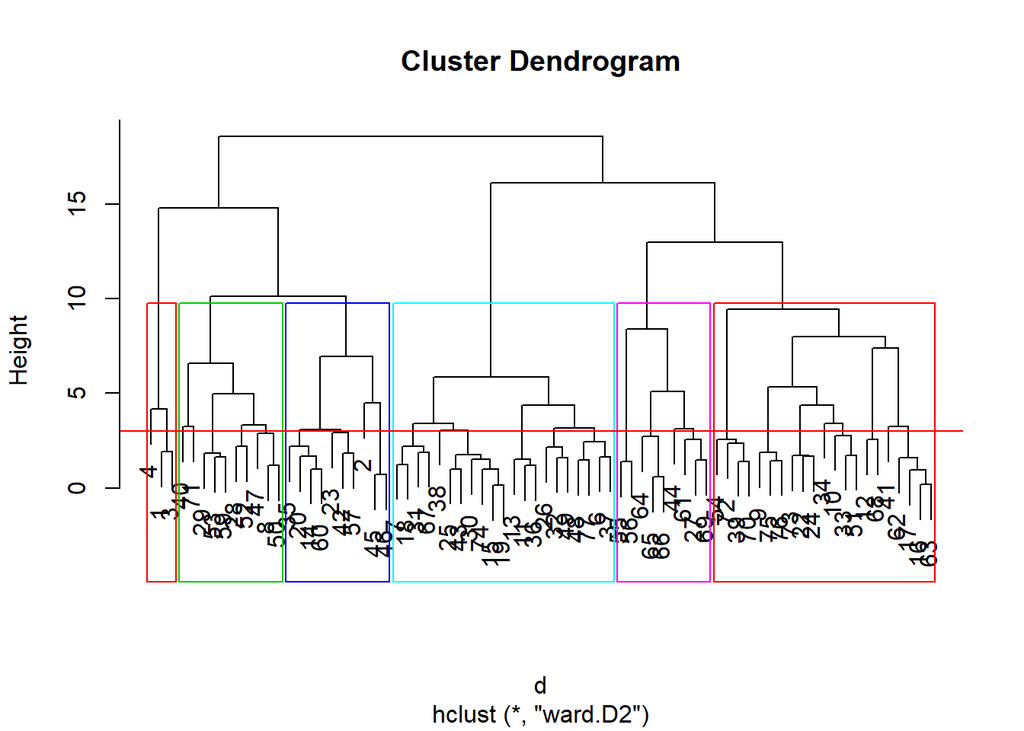

```r
#cutree function is useful to cut the dendogram
#suppose when clusters (k)=6

points_hc <- cutree(hc1,k=6)
plot(hc1)
rect.hclust(hc1 , k = 6, border = 2:6)
abline(h = 3, col = 'red')
```

```r
table(points_hc)
```

```
## points_hc
##  1  2  3  4  5  6
##  3 10 21 10 21  9
```

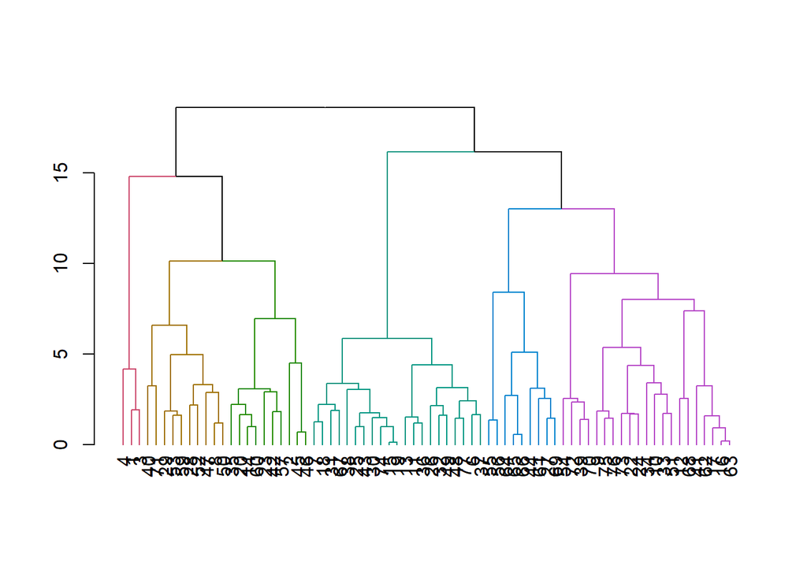

```r
#Using different colors for each clusters
avg_dend_obj <- as.dendrogram(hc1)
avg_col_dend <- color_branches(avg_dend_obj, h = 10)
plot(avg_col_dend)
```

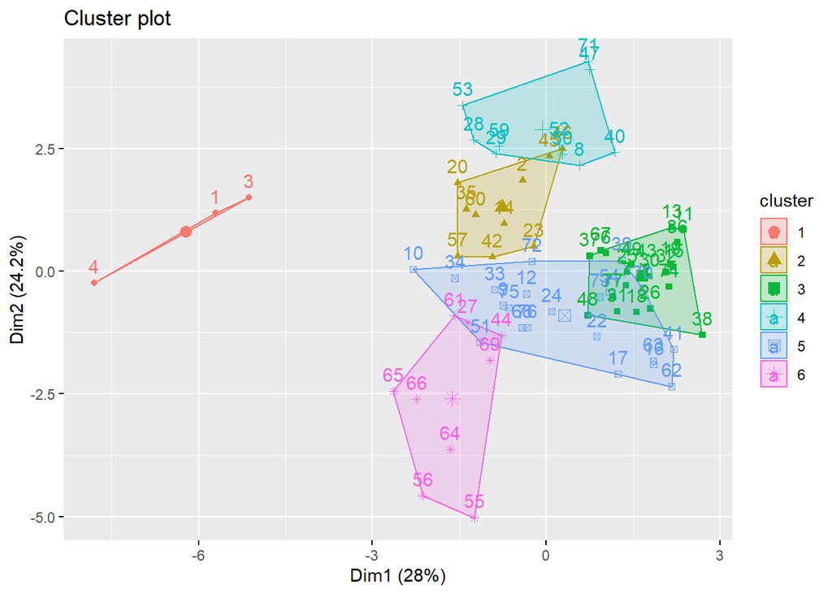

```r
#Visiualizing clusters
data_cluster <- data.frame(cbind(data = data_cereal, cluster = points_hc))
data_cereal1 <- data.frame(data_cereal)
fviz_cluster(list(data = data_cereal, cluster = points_hc))
```

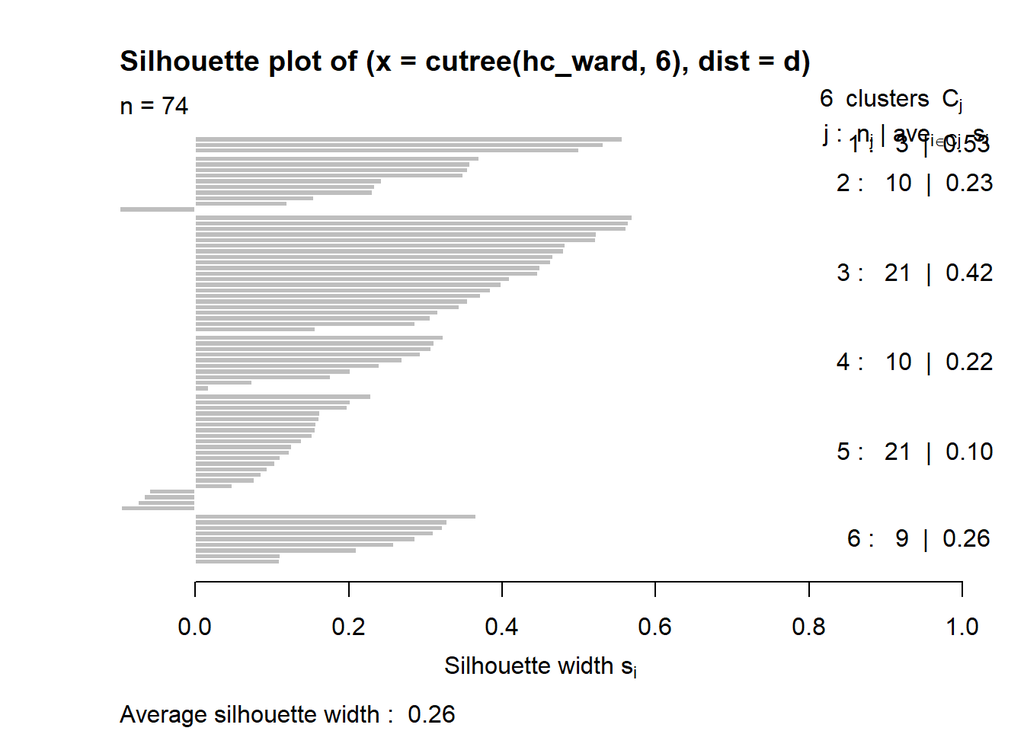

```r
#table(points_hc,data_cereal1$rating)

#Using silhouette to analyse clusters
plot(silhouette(cutree(hc_ward,6),d))
```

```r
datanew <- cereal[,c(-1,-2,-3)]

# Silhouette width of observation

res.hc <- eclust(datanew, "hclust", k = 6,
                 method = "ward.D2", graph = FALSE)
head(res.hc$cluster, 15)
```

```
##  [1] 1 2 1 1 3 3 4 3 3 5 3 6 3 3 3
```

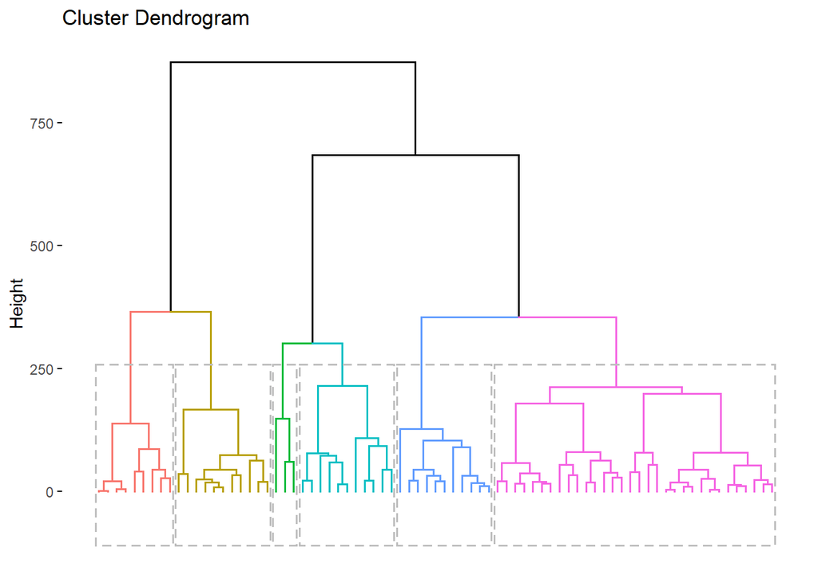

```r
fviz_dend(res.hc, rect = TRUE, show_labels = FALSE)
```

```
##   cluster size ave.sil.width
## 1       1    3          0.32
## 2       2   11          0.55
## 3       3   32          0.23
## 4       4    9          0.40
## 5       5   11          0.26
## 6       6   11          0.43
```

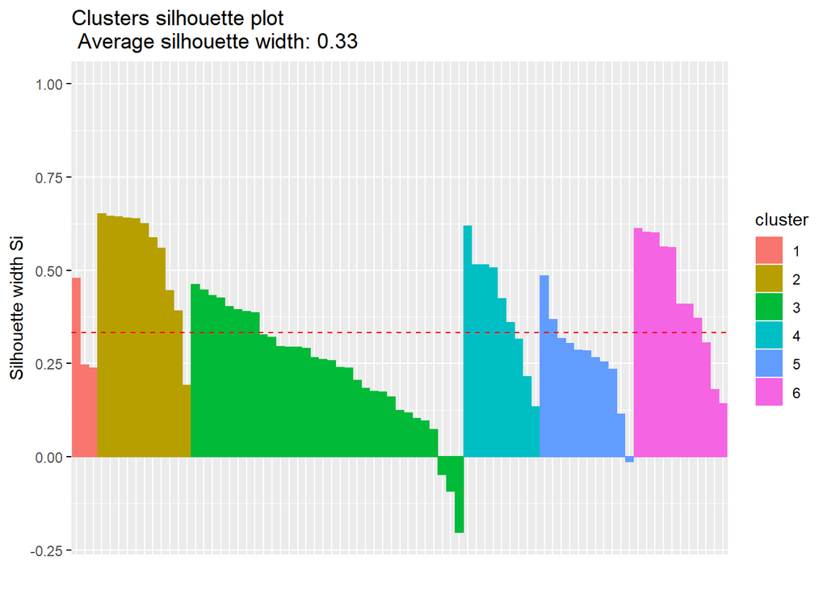

```r
fviz_silhouette(res.hc)
```

```r
sil <- res.hc$silinfo$widths[, 1:3]

# Objects with negative silhouette

neg_sil_index <- which(sil[, 'sil_width'] < 0)
sil[neg_sil_index, , drop = FALSE]
```

```
##    cluster neighbor   sil_width
## 36       3        6 -0.04756114
## 11       3        6 -0.09324474
## 37       3        6 -0.20259619
## 60       5        3 -0.01267310
```

3. Comment on the structure of the clusters and on their stability.

```r
#Source:R-bloggers(online)
k_choosen <- 6
cboot.hclust <- clusterboot(data_cereal,clustermethod=hclustCBI,
                           method="ward.D2", k=k_choosen)
```

[output not shown]

[output cut: 45 more lines]

[output not shown]

```r
summary(cboot.hclust$result)
```

```
##               Length Class  Mode
## result         7     hclust list
## noise          1     -none- logical
## nc             1     -none- numeric
## clusterlist    6     -none- list
## partition     74     -none- numeric
## clustermethod  1     -none- character
## nccl           1     -none- numeric
```